# Exercise 02 – Forest Structural Complexity Exploration

Cesar Alvites - Forest Biometrics, Remote Sensing and Artificial Intelligence Lab (SilvaLab). School of Forest, Fisheries and Geomatics Science, University of Florida, PO Box 110410 Gainesville, FL, USA 32611

2026-02-09

# 1 Objective

The entire processing workflow is implemented in R, providing a fully reproducible and open-source environment for processing, analysing, and visualising airborne LiDAR data for forest and ecological applications.

# 2 Methodology

The exercise follows a sequential, grid-based workflow. First, raw ALS point cloud data are read, inspected, and projected to a common coordinate reference system. ALS point clouds are normalized and classified. Forest structural complexity is then quantified on a regular grid by summarising the normalised LiDAR point cloud within each pixel. Multiple complementary metrics are computed to describe different dimensions of canopy structure, including vertical variability, vertical layering and diversity, and spatial heterogeneity. Together, these metrics provide a spatially explicit representation of forest structural complexity across the study area.

# 3 Input data

1. Airborne laser scanning (.laz / .las)

# 4 Expected output

1. HSD (Height Standard Deviation) – a measure of vertical variability in canopy height within each grid cell.
2. VCI (Vertical Complexity Index) – a normalised index describing the diversity and evenness of vertical canopy layers.
3. CRR (Canopy Relief Ratio) – a measure representing the relative shape and vertical complexity of a forest canopy.

# 5 R packages

# 6 Hands-on Steps

## 6.1 Loading R packages

```r
packages <- c(
  "lidR",
  "RCSF",
  "terra",
  "sf",
  "dplyr",
  "ggplot2",
  "plot3D"
)

# install only missing packages
missing_pkgs <- packages[!packages %in% installed.packages()[, "Package"]]

if (length(missing_pkgs) > 0) {
  install.packages(missing_pkgs, dependencies = TRUE)
}

# load packages quietly
suppressMessages(
  lapply(packages, library, character.only = TRUE)
)
```

## 6.2 Loading raw LiDAR data

LiDAR point clouds are commonly distributed in several formats, including LAS, LAZ, PLY, and others. Here, users can upload LiDAR datasets by selecting the desired file path. Once loaded, key LiDAR features such as coordinate system, point density, number of points, memory usage, and acquisition type are printed to support informed processing decisions.

```r
# ============================================================
# 1. LiDAR File Selection
# ============================================================
las_path <- file.choose()  # Select LAS/LAZ file interactively

# ============================================================
# 2. LiDAR Data Import with Fallback Reader
# ============================================================
las <- tryCatch(
  readALSLAS(las_path),
  error = function(e) {
    message("readALSLAS() failed. Using lidR::readLAS() instead.")
    lidR::readLAS(las_path)
  }
)  # Read LiDAR file with robust error handling

# ============================================================
# 3. Input Data Validation
# ============================================================
if (is.empty(las)) stop("LAS file is empty")  # Stop if no points are present

# ============================================================
# 4. Coordinate Reference System Assignment
# ============================================================
#lidR::projection(las) <- sf::st_crs(32633)  # Assign projected CRS (UTM zone 33N)

# ============================================================
# 5. LiDAR Object Inspection
# ============================================================
# ============================================================
# 6. Point Density and Point Spacing (Global Metrics)
# ============================================================
# Point density (pts/m²) represents the average number of LiDAR points
# per unit area over the entire dataset. By default, it considers ALL
# returns stored in the LAS file (first, intermediate, and last returns).

# Point spacing (m or cm) is the theoretical average distance between
# neighboring LiDAR points, derived from total area and total point count.
# It is a global summary metric and does NOT describe local point spacing
# or pulse spacing.

las
# cat("------------\n")
# A <- area(las)
# cat("Point spacing (cm):", sqrt(A/npoints(las))*100, "\n")
# cat("Point density (pts/m^2):", npoints(las)/A, "\n")
```

[output not shown]

## 6.3 CRS transformation and Z conversion from US survey feet to meters

```r
las <- sf::st_transform(las, sf::st_crs(5070))
las$Z <- las$Z * 0.304800609
```

## 6.4 Small 3D visualization (didactic example)

This step extracts a small circular subset of the LiDAR point cloud and displays it in 3D to visually illustrate canopy structure, height variation, and point distribution before further processing.

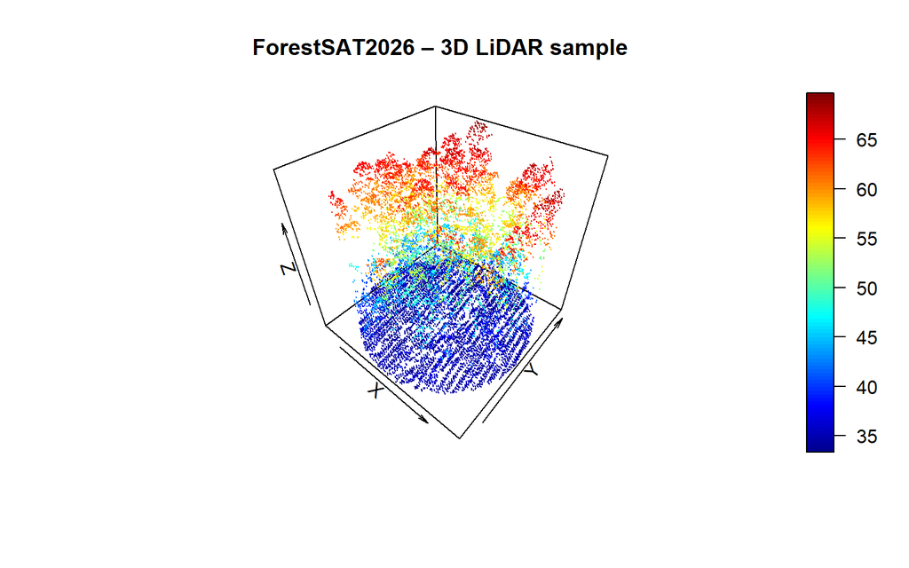

## 6.5 Ground classification using Cloth Simulation Filter (CSF)

Ground classification separates terrain points from vegetation and objects, essential for terrain models and normalising LiDAR heights. Ground points are identified using the Cloth Simulation Filter (CSF: Zhang et al., 2016), which simulates a virtual cloth over the inverted point cloud. Parameters control cloth resolution, rigidity, and convergence, adapting to terrain roughness. The classified point cloud offers a reliable ground surface for terrain and canopy analysis.

```r
las_g <- classify_ground(las,
                         csf(sloop_smooth=FALSE, class_threshold=0.5,
                             cloth_resolution=0.5, rigidness=1L,
                             iterations=500L, time_step=0.65))
```

## 6.6 Height normalization of LiDAR point clouds

Height normalisation is the process of transforming raw LiDAR elevation values into heights relative to the ground surface. By removing the influence of terrain variability, this step enables vegetation and object heights to be compared consistently across areas with different elevations and slopes.

Several methods can be used for height normalisation, depending on data characteristics and terrain complexity. Common approaches include:

- Raster-based normalisation, where point elevations are adjusted using a Digital Terrain Model (DTM)
- k-nearest-neighbour interpolation, which estimates ground height locally from nearby ground points
- TIN(Triangulated Irregular Network)-based normalisation, which models the terrain as a triangulated irregular network

In this workflow, a TIN-based method is adopted because it provides a balanced and flexible representation of the terrain surface, particularly in areas with variable topography. This approach effectively preserves local ground variations while ensuring robust normalisation for canopy structure analysis.

```r
# ============================================================
# 1. Height Normalization of LiDAR Point Cloud
# ============================================================
nlas <- normalize_height(las, tin())  # Normalize heights using TIN-based ground model

# ============================================================
# 2. Filtering of Non-Physical Points
# ============================================================
nlas <- filter_poi(nlas, Z >= 0 & Z <= quantile(Z, 0.99, na.rm = TRUE))
```

## 6.7 Forest complexity mapping

In this step, forest structural complexity is mapped across the entire area of interest using a regular grid (e.g., 3 m). Metrics are computed directly from the height-normalised LiDAR point cloud (heights above ground) by summarising points within each grid cell using the pixel_metrics() function from the lidR package. These metrics capture complementary aspects of vertical variability, vertical complexity, and canopy rugosity, which are key descriptors of forest structure beyond simple canopy height or cover.

- Height Standard Deviation (HSD)

Height Standard Deviation (HSD) quantifies vertical variability within each grid cell and reflects the spread of canopy heights. Higher values indicate vertically heterogeneous or multi-layered canopies, while low values indicate uniform or simple vertical structure.

$$HSD = \sqrt{\frac{1}{n-1}\sum_{i=1}^{n}\left[z_i - \bar{z}\right]^2}
\qquad \text{(Eq1)}$$

where $z_i$ are normalised LiDAR heights and $\bar{z}$ is their mean.

-Vertical Complexity Index (VCI)

The Vertical Complexity Index (VCI) describes the evenness of the vertical distribution of canopy elements across height layers. Following the Shannon entropy formulation, VCI ranges from 0 to 1, where higher values indicate a more evenly distributed (vertically complex) canopy and lower values indicate concentration of vegetation within few height layers.

$$VCI = \frac{-\sum_{h=1}^{H} p_h \ln\left[p_h\right]}{\ln\left[H\right]}
\qquad \text{(Eq2)}$$

where $p_h$ is the proportion of LiDAR returns in height layer $h$, and $H$ is the total number of occupied height layers within the pixel.

-Canopy Relief Ratio (CRR)

The Canopy Relief Ratio (CRR) measures relative canopy rugosity, describing how canopy mass is distributed between lower and upper canopy layers. CRR is dimensionless and ranges between 0 and 1. Values closer to 1 indicate canopy mass concentrated near the top of the canopy (top-heavy or vertically complex structure), while lower values indicate bottom-heavy or vertically uniform canopies.

$$CRR = \frac{\bar{z} - z_{\min}}{z_{\max} - z_{\min}}
\qquad \text{(Eq3)}$$

where $\bar{z}$ is the mean canopy height, $z_{\min}$ is the minimum height (ground level), and $z_{\max}$ is the maximum canopy height within the pixel.

```r
VCI_fun <- function(Z, dz = 1, zmin = 0.5, n_min = 10) {

  # keep canopy points only (above zmin) and finite values
  Z <- Z[is.finite(Z) & Z > zmin]
  if (length(Z) < n_min) return(NA_real_)

  zmax <- max(Z, na.rm = TRUE)

  # if canopy heights fall in a single layer, VCI = 0
  # (need at least 2 bins => at least 2 breaks)
  if (!is.finite(zmax) || zmax < (zmin + dz)) return(0)

  # build breaks (ensure >= 2 breaks)
  brks <- seq(zmin, ceiling(zmax), by = dz)
  if (length(brks) < 2) return(0)

  bins <- cut(Z, breaks = brks, include.lowest = TRUE, right = FALSE)

  p <- prop.table(table(bins))
  p <- p[p > 0]

  H <- length(p)           # number of occupied height layers
  if (H <= 1) return(0)    # no vertical diversity

  # normalized Shannon entropy (0..1)
  as.numeric(-sum(p * log(p)) / log(H))
}

CRR_fun <- function(Z, baseline = 0, n_min = 10) {
  Z <- Z[is.finite(Z)]
  if (length(Z) < n_min) return(NA_real_)

  zmax <- max(Z, na.rm = TRUE)
  if (!is.finite(zmax) || zmax <= baseline) return(NA_real_)

  as.numeric((mean(Z, na.rm = TRUE) - baseline) / (zmax - baseline))
}

struct_metrics <- function(Z) {
  list(
    HSD = sd(Z, na.rm = TRUE),
    VCI = VCI_fun(Z),
    CRR = CRR_fun(Z)
  )
}

struct_stack <- pixel_metrics(
  nlas,
  ~struct_metrics(Z),
  res = 3,
  progress = FALSE
)

names(struct_stack)
```

```
## [1] "HSD" "VCI" "CRR"
```

```r
# "HSD" "VCI" "CRR"
```

## 6.8 Visualization of raster products

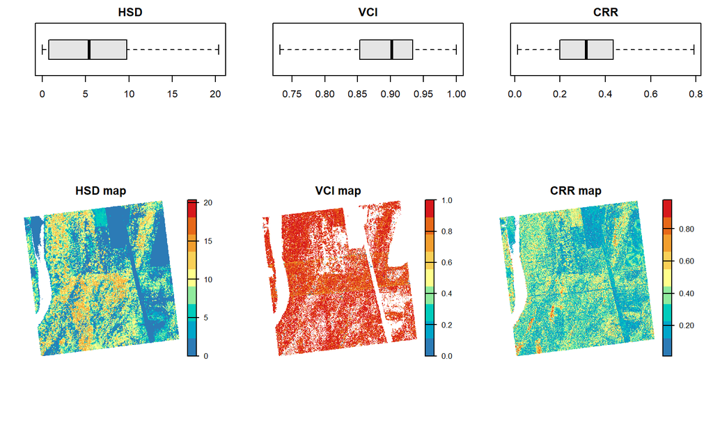

## 6.9 Export outputs

```r
out_dir <- file.path(dirname(las_path), "ForestSAT2026_02_Exercise")
dir.create(out_dir, showWarnings=FALSE)
terra::writeRaster(struct_stack[["HSD"]], file.path(out_dir, "HSD.tif"),overwrite = TRUE)
terra::writeRaster(struct_stack[["VCI"]], file.path(out_dir, "VCI.tif"), overwrite =TRUE)
terra::writeRaster(struct_stack[["CRR"]], file.path(out_dir, "CRR.tif"), overwrite =TRUE)
```

## 6.10 Reference

- Alvites, C., Marchetti, M., Lasserre, B., & Santopuoli, G. (2022). LiDAR as a tool for assessing timber assortments: A systematic literature review. *Remote Sensing, 14*(18), 4466.
- Bruggisser, M., Hollaus, M., Kükenbrink, D., & Pfeifer, N. (2019). Comparison of forest structure metrics derived from UAV lidar and ALS data. ISPRS Annals of the Photogrammetry, Remote Sensing and Spatial Information Sciences, 4, 325-332.
- Silva, C. A., Crookston, N. L., Hudak, A. T., Vierling, L. A., Klauberg, C., & Silva, M. C. A. (2017). *rLiDAR*: An R package for LiDAR data processing. CRAN.
- Roussel, J.-R., Auty, D., Coops, N. C., Tompalski, P., Goodbody, T. R. H., Meador, A. S., & Achim, A. (2020). lidR: An R package for analysis of Airborne Laser Scanning (ALS) data. *Remote Sensing of Environment, 251*, 112061.
- Hijmans, R. J., Van Etten, J., Cheng, J., Mattiuzzi, M., Sumner, M., & Greenberg, J. A. (2015). *raster*: Geographic data analysis and modeling. CRAN.
- Hijmans, R. J., Bivand, R., Forner, K., Ooms, J., Pebesma, E., & Sumner, M. D. (2022). *terra*: Spatial data analysis. CRAN.
- Wright, M. N., Wager, S., Probst, P., & Wright, M. M. N. (2019). *ranger*: A fast implementation of Random Forests. CRAN.
- Chen, T., He, T., Benesty, M., & Khotilovich, V. (2019). *xgboost*: Extreme Gradient Boosting. CRAN.
- Zhang, W., Qi, J., Wan, P., Wang, H., Xie, D., Wang, X., & Yan, G. (2016). An easy-to-use airborne LiDAR data filtering method based on cloth simulation. Remote sensing, 8(6), 501.

# 7 Key takeaways

1.**ALS enables explicit mapping of forest structural complexity, not just height or cover.**. Metrics like height standard deviation (HSD), vertical complexity index (VCI), and canopy relief ratio (CRR) measure various aspects of canopy structure, offering a richer description than mean height alone.

2.**Different complexity metrics capture complementary structural properties.** HSD measures vertical variability, VCI reflects the diversity and evenness of height layers, and CRR indicates biomass position within the canopy; together, they distinguish simple from complex, heterogeneous forests.

3.**Forest complexity maps are highly sensitive to LiDAR preprocessing and scaling choices.**Height normalization, noise filtering, grid resolution, and outlier handling heavily impact complexity metrics, so visual inspection and parameter testing are crucial to confirm ecologically meaningful patterns.